# Introducing the Text Prediction Cloud App

Travis Fell  
April 20, 2016

### Overview of the Text Prediction Cloud App

This simple and straight forward app predicts words from your entered text and displays it in one of two ways

- Top 3 most likely: Like handheld device keyboard apps, this app shows the top three most likely next words
- Word cloud: Expand the possibilities by seeing a word cloud of the top 25 predicted words.

### Method

Below is an overview of the data processing, algorithm and testing methods for this app.

1. Pulled a 10% sample of US news stories, tweets and blog posts.
2. Subdivided the corpus into an 80/20 training/test set.
3. Created unigram and bigram lists along with frequencies of each.
4. Developed a Knesser-Ney algorithm using the bigram and unigram lists.
5. Developed a testing algorithm that randomly sampled the test set 20 times and recorded how often the model predicted the last word within the top 3 results. After 10 simulations, the model consistently had betwen a 20% and 25% success rate.

### Algorithm

The code below summarizes the Kneser-Ney model the app uses.

```r
wi_1 <- enteredtext
wi_1 <- unlist(strsplit(wi_1, " "))[length(unlist(strsplit(wi_1, " ")))]
matchingbigrams <- bifreq[grep(paste("^",wi_1,"_", sep = ""), names(bifreq))]
unigram_ct_wi_1 <- unifreq[[grep(paste("^", wi_1, "$", sep = ""), names(unifreq))]]
D <- .75
lambda <- D/unigram_ct_wi_1 * length(grep(paste("^",wi_1,"_", sep = ""), names(bifreq)))
p_continuation_w <- length(grep(paste("^",wi_1,"_", sep = ""), names(bifreq)))
totalBigramTypes <- length(bifreq)
bigram_ct_wi_1 <- sum(bifreq[(grep(paste("^",wi_1,"_", sep = ""), names(bifreq)))] - D)
for (i in 1:length(matchingbigrams)) {
  bigram_ct_wi_1 <- matchingbigrams[[i]] - D
  matchingbigrams[i] <- max(bigram_ct_wi_1/unigram_ct_wi_1, 0) + lambda * (p_continuation_w/totalBigramTypes) }
```

### Demo

Text Word Cloud is easy to use. Just 1) type in your text, 2) click Submit, and 3) watch the prediction magic and word cloud happen!

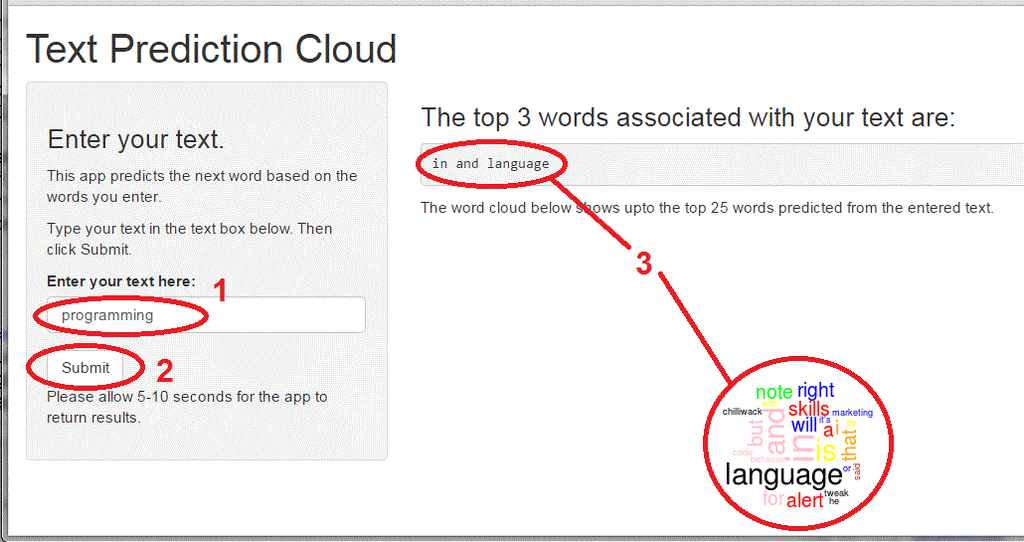

### Take the Next Step

Start your text prediction adventure today: https://tfell2001.shinyapps.io/CapstoneWordPredict/